# Data Analysis and Linear Models Homework 8

### 1.Introduction

This project is about that using the data of residential sales that occurred during the year 2002 were available from a city in the midwest to bulid a model to predict the sales price.These demographic variable include sales price, style, finished square feet, number of bedrooms, whether the house has a pool, lot size, year built, whether air conditioning is installed and whether or not the lot is adjacent to a highway.

```
## 'data.frame':    522 obs. of  13 variables:
##  $ Id.Number          : int  1 2 3 4 5 6 7 8 9 10 ...
##  $ Sales.Price        : int  360000 340000 250000 205500 275500 248000 229900 150000 195000 160000 ...
##  $ Square.Feet        : int  3032 2058 1780 1638 2196 1966 2216 1597 1622 1976 ...
##  $ Number.bedrooms    : int  4 4 4 4 4 4 3 2 3 3 ...
##  $ Number.Bathrooms   : int  4 2 3 2 3 3 2 1 2 3 ...
##  $ Air.Condition      : Factor w/ 2 levels "0","1": 2 2 2 2 2 2 2 2 2 1 ...
##  $ Garage.Size        : int  2 2 2 2 2 5 2 1 2 1 ...
##  $ Pool               : Factor w/ 2 levels "0","1": 1 1 1 1 1 2 1 1 1 1 ...
##  $ Year.Built         : int  1972 1976 1980 1963 1968 1972 1972 1955 1975 1918 ...
##  $ Quality            : Factor w/ 3 levels "1","2","3": 2 2 2 2 2 2 2 2 3 3 ...
##  $ Style              : Factor w/ 10 levels "1","2","3","4",..: 1 1 1 1 7 1 7 1 1 1 ...
##  $ Lot.Size           : int  22221 22912 21345 17342 21786 18902 18639 22112 14321 32358 ...
##  $ Adjacent.to.Highway: Factor w/ 2 levels "0","1": 1 1 1 1 1 1 1 1 1 1 ...
```

#### 2.Exploratory data analysis

#### (a)

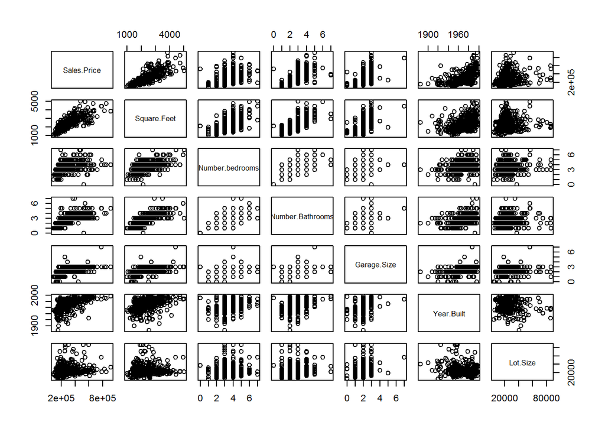

#### (b)

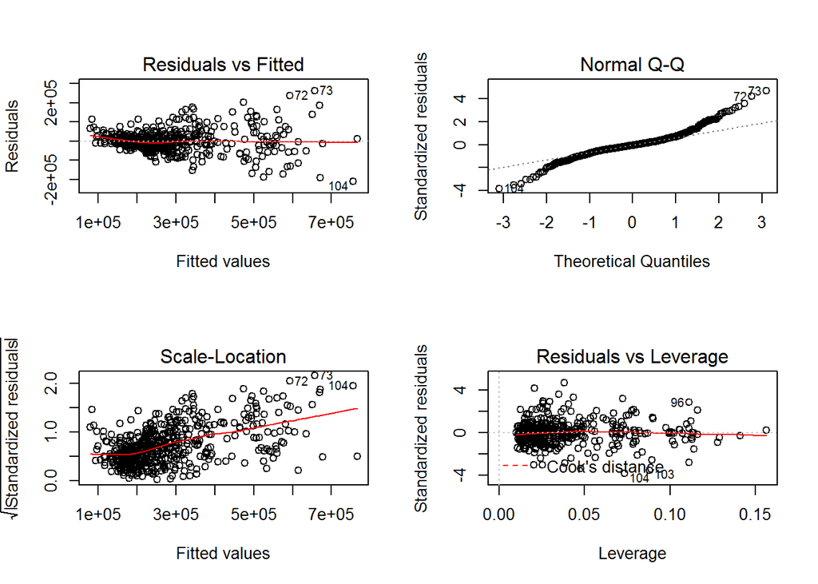

```
Residual vs Fitted values in plot(1) has a trend of funnel shape,which indicates error terms in model has a nonconstant variables.This is not To meet the equal variance conditions;
The QQ-plot of residual in plot(2) show us that the error term in model is not to meet the normality condition;
And the plot(3),(4) tell us that there are outliers in raw dataset.
So model assumptions are violated.
```

Make a transformation in predictive variables *Square.Feet,Lot.Size* and response variable *Sales.Price* with **log10**

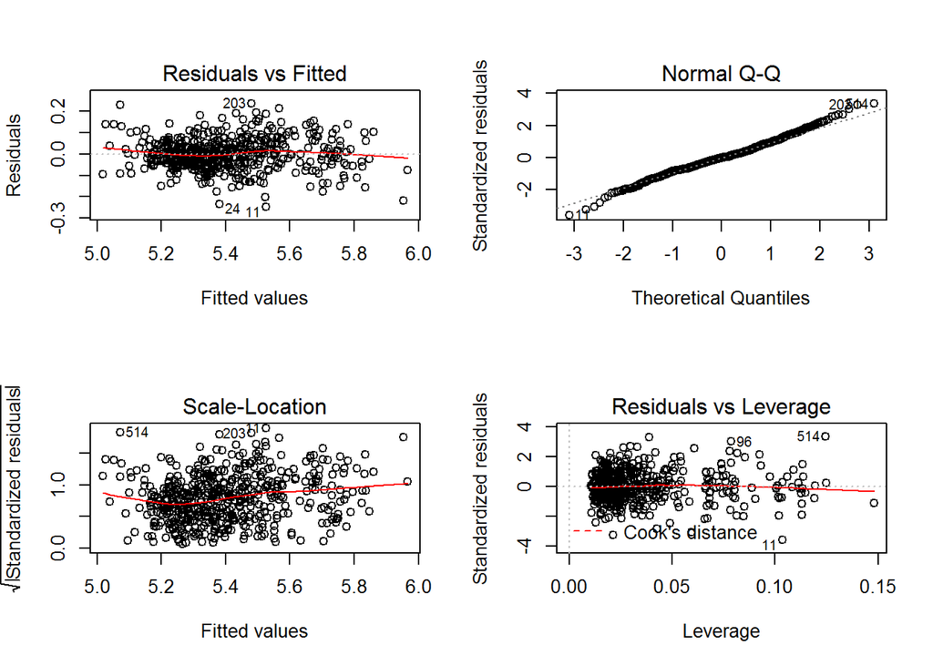

Afther the data transformation ,we bulid the model again.According to the plot of model.These graph show us that model assumations are not violated.

#### (c)

- i

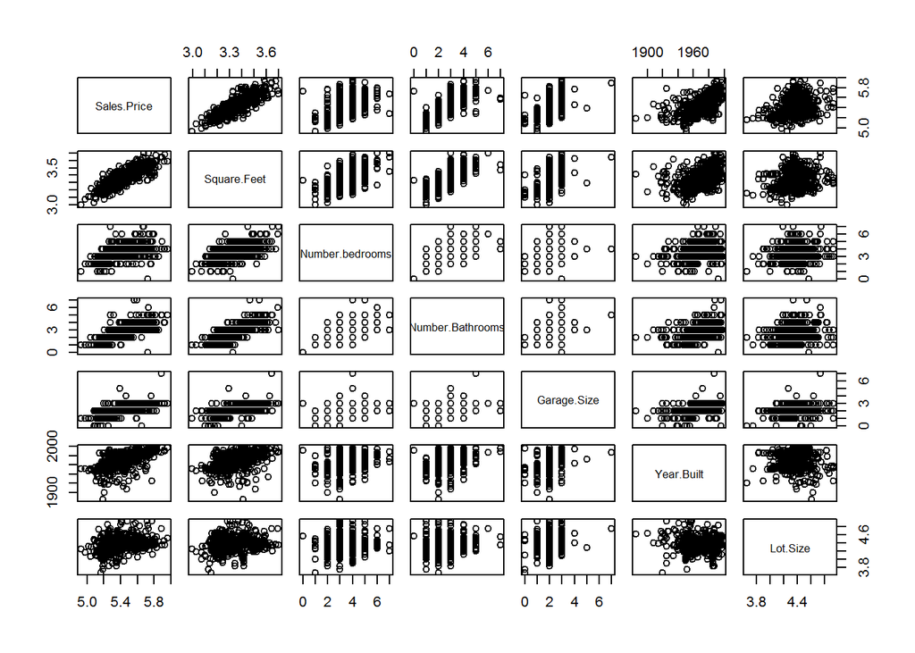

  The linear relationship perform more stronger in scatterplot of response variable and predictive variables.
- ii *Air.Condition,Pool,Quality,Style,Adjacent.to.Highway* are qualitative variables

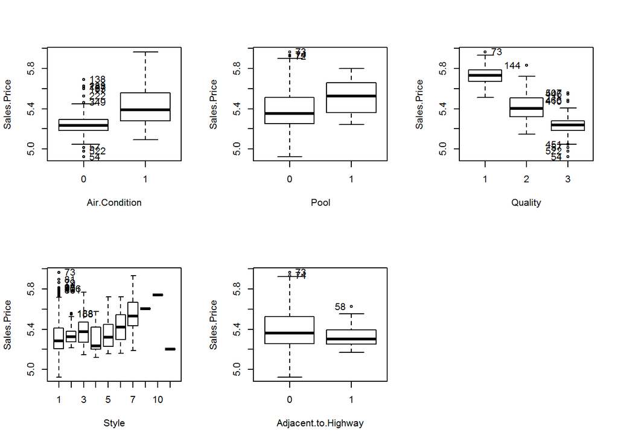

- iii

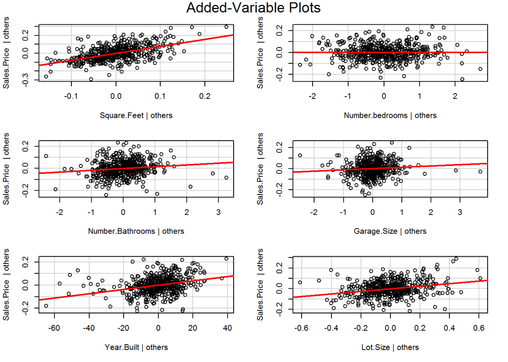

- iv

### 3.Model building

#### (a)

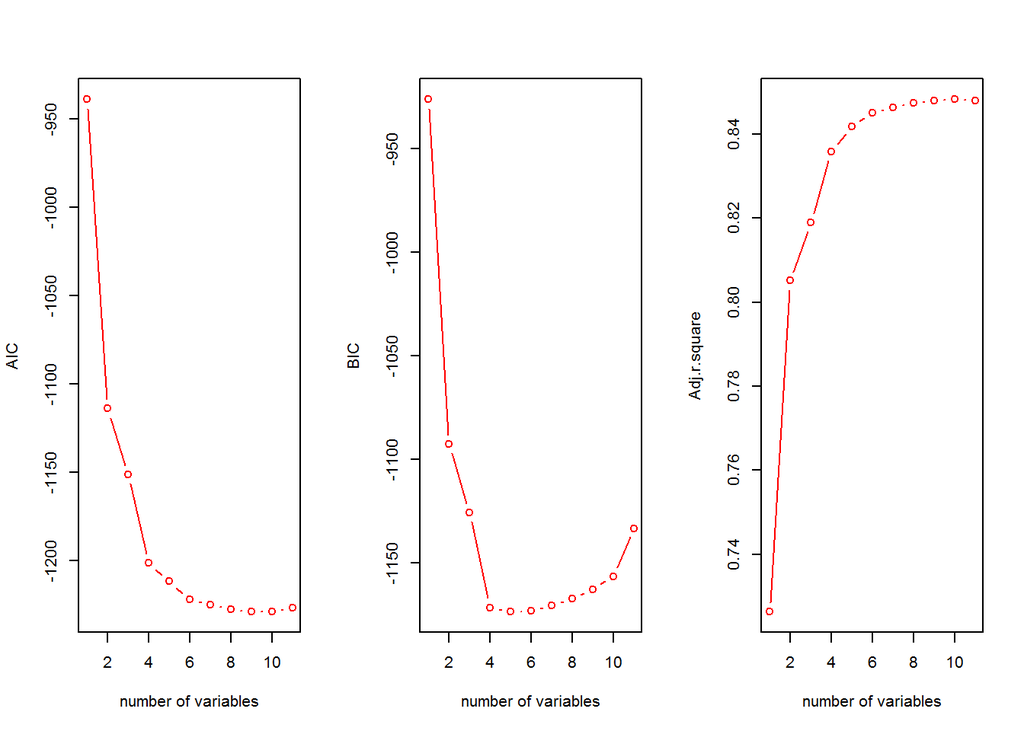

#### (b)

```
## Five model variable subsets in AIC:....
```

```
## [[1]]
## [1] "Square.Feet"         "Number.Bathrooms"    "Garage.Size"
## [4] "Pool"                "Year.Built"          "Quality"
## [7] "Style"               "Lot.Size"            "Adjacent.to.Highway"
##
## [[2]]
##  [1] "Square.Feet"         "Number.Bathrooms"    "Air.Condition"
##  [4] "Garage.Size"         "Pool"                "Year.Built"
##  [7] "Quality"             "Style"               "Lot.Size"
## [10] "Adjacent.to.Highway"
##
## [[3]]
## [1] "Square.Feet"      "Number.Bathrooms" "Garage.Size"
## [4] "Pool"             "Year.Built"       "Quality"
## [7] "Style"            "Lot.Size"
##
## [[4]]
##  [1] "Square.Feet"         "Number.bedrooms"     "Number.Bathrooms"
##  [4] "Air.Condition"       "Garage.Size"         "Pool"
##  [7] "Year.Built"          "Quality"             "Style"
## [10] "Lot.Size"            "Adjacent.to.Highway"
##
## [[5]]
## [1] "Square.Feet"      "Number.Bathrooms" "Pool"
## [4] "Year.Built"       "Quality"          "Style"
## [7] "Lot.Size"
```

```
## Five model variable subsets in BIC:....
```

```
## [[1]]
## [1] "Square.Feet"      "Number.Bathrooms" "Year.Built"
## [4] "Quality"          "Lot.Size"
##
## [[2]]
## [1] "Square.Feet"      "Number.Bathrooms" "Garage.Size"
## [4] "Year.Built"       "Quality"          "Lot.Size"
##
## [[3]]
## [1] "Square.Feet" "Year.Built"  "Quality"     "Lot.Size"
##
## [[4]]
## [1] "Square.Feet"      "Number.Bathrooms" "Garage.Size"
## [4] "Pool"             "Year.Built"       "Quality"
## [7] "Lot.Size"
##
## [[5]]
## [1] "Square.Feet"      "Number.Bathrooms" "Air.Condition"
## [4] "Garage.Size"      "Pool"             "Year.Built"
## [7] "Quality"          "Lot.Size"
```

```
## Five model variable subsets in Adj.r.square:....
```

```
## [[1]]
##  [1] "Square.Feet"         "Number.Bathrooms"    "Air.Condition"
##  [4] "Garage.Size"         "Pool"                "Year.Built"
##  [7] "Quality"             "Style"               "Lot.Size"
## [10] "Adjacent.to.Highway"
##
## [[2]]
## [1] "Square.Feet"         "Number.Bathrooms"    "Garage.Size"
## [4] "Pool"                "Year.Built"          "Quality"
## [7] "Style"               "Lot.Size"            "Adjacent.to.Highway"
##
## [[3]]
##  [1] "Square.Feet"         "Number.bedrooms"     "Number.Bathrooms"
##  [4] "Air.Condition"       "Garage.Size"         "Pool"
##  [7] "Year.Built"          "Quality"             "Style"
## [10] "Lot.Size"            "Adjacent.to.Highway"
##
## [[4]]
## [1] "Square.Feet"      "Number.Bathrooms" "Garage.Size"
## [4] "Pool"             "Year.Built"       "Quality"
## [7] "Style"            "Lot.Size"
##
## [[5]]
## [1] "Square.Feet"      "Number.Bathrooms" "Pool"
## [4] "Year.Built"       "Quality"          "Style"
## [7] "Lot.Size"
```

According to the result ,there models are generally the similiar.variable *Square.Feet* is consistently present in all the “best” sub-models.

#### (c)

```
##
## Call:
## lm(formula = Sales.Price ~ Square.Feet + Number.Bathrooms + Garage.Size +
##     Pool + Year.Built + Quality + Style + Lot.Size + Adjacent.to.Highway,
##     data = sales.new)
##
## Coefficients:
##          (Intercept)           Square.Feet      Number.Bathrooms
##            -1.441120              0.786642              0.016416
##          Garage.Size                 Pool1            Year.Built
##             0.013251              0.028017              0.001907
##             Quality2              Quality3                Style2
##            -0.124295             -0.156612             -0.029761
##               Style3                Style4                Style5
##            -0.008087              0.031273             -0.029378
##               Style6                Style7                Style9
##            -0.004407             -0.048421             -0.053670
##              Style10               Style11              Lot.Size
##            -0.110174             -0.166064              0.122398
## Adjacent.to.Highway1
##            -0.040835
```

We can get the stepwise model function from the above result.This model is :

- *Sales.Price*~*Square.Feet* + *Number.Bathrooms* + *Garage.Size* + *Pool* + *Year.Built* + *Quality* + *Style* + *Lot.Size* + *Adjacent.to.Highway*

This model is identified by this procedure the same as any of the one identified in part (b).

#### (d)

I pick the two model below:

- 1. model.3: *Sales.Price*~*Square.Feet* + *Number.Bathrooms* + *Garage.Size* + *Pool* + *Year.Built* + *Quality* + *Style* + *Lot.Size* + *Adjacent.to.Highway*
- 2. model.4: *Sales.Price*~*Square.Feet* + *Number.Bathrooms* + *Garage.Size* +*Year.Built* + *Quality* + *Lot.Size*

### 4.Model Diagnostic

#### (a)

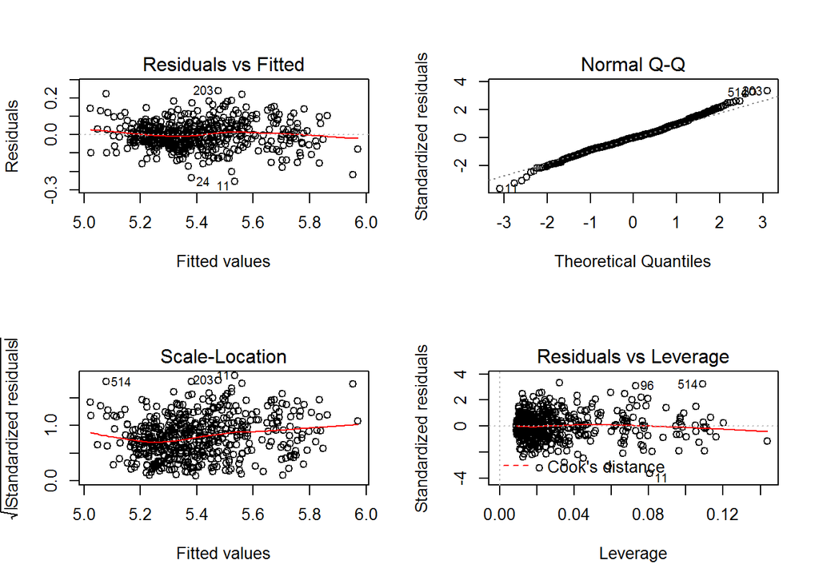

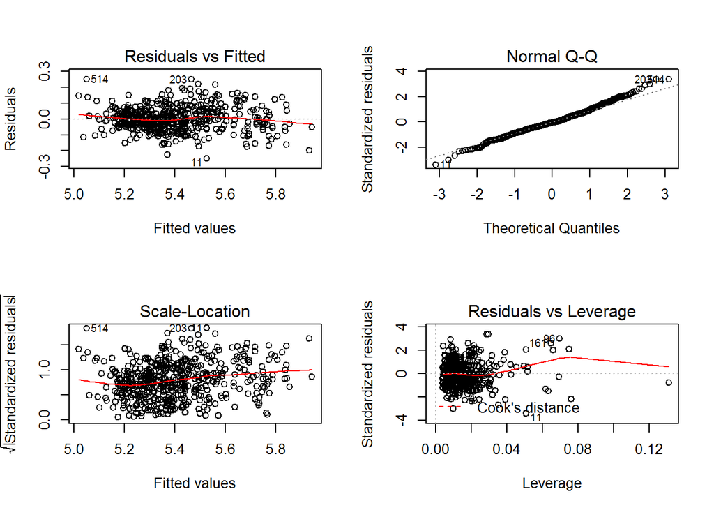

The “traditional” residual plots of the picked model show that,the errom term in two model both meet the cosntannt variance and k normality assumations.

#### (b)

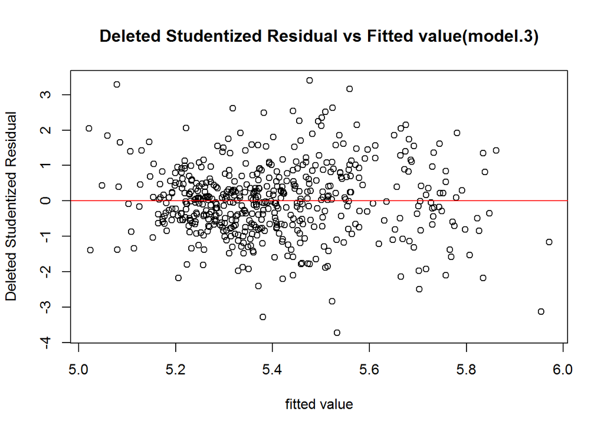

```
## Use the t-test to compare difference between semi-studentized
## residuals  and deleted studentized residual...
```

```
##
##  Welch Two Sample t-test
##
## data:  semi.student.res.3 and stud.re.del.3
## t = -0.00058339, df = 526.91, p-value = 0.9995
## alternative hypothesis: true difference in means is not equal to 0
## 95 percent confidence interval:
##  -1.159514  1.158825
## sample estimates:
##    mean of x    mean of y
## 1.269538e-16 3.442411e-04
```

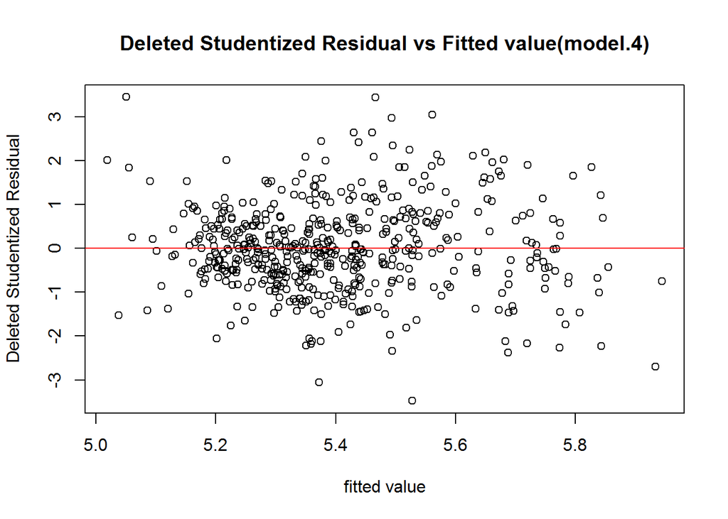

```
## Use the t-test to compare difference between semi-studentized
## residuals  and deleted studentized residual...
```

```
##
##  Welch Two Sample t-test
##
## data:  semi.student.res.4 and stud.re.del.4
## t = -0.0010062, df = 527.06, p-value = 0.9992
## alternative hypothesis: true difference in means is not equal to 0
## 95 percent confidence interval:
##  -1.141135  1.139967
## sample estimates:
##     mean of x     mean of y
## -1.667196e-16  5.841749e-04
```

#### (c)

```
##
## Call:
## lm(formula = Sales.Price ~ Square.Feet + Number.Bathrooms + Garage.Size +
##     Pool + Year.Built + Quality + Style + Lot.Size + Adjacent.to.Highway,
##     data = sales.new)
##
## Residuals:
##       Min        1Q    Median        3Q       Max
## -0.254792 -0.045087 -0.000605  0.040855  0.239287
##
## Coefficients:
##                        Estimate Std. Error t value Pr(>|t|)
## (Intercept)          -1.4411199  0.5573499  -2.586   0.0100 **
## Square.Feet           0.7866422  0.0541325  14.532  < 2e-16 ***
## Number.Bathrooms      0.0164158  0.0052027   3.155   0.0017 **
## Garage.Size           0.0132513  0.0063104   2.100   0.0362 *
## Pool1                 0.0280167  0.0131992   2.123   0.0343 *
## Year.Built            0.0019065  0.0002587   7.370 7.07e-13 ***
## Quality2             -0.1242946  0.0127578  -9.743  < 2e-16 ***
## Quality3             -0.1566121  0.0177976  -8.800  < 2e-16 ***
## Style2               -0.0297611  0.0116109  -2.563   0.0107 *
## Style3               -0.0080870  0.0110803  -0.730   0.4658
## Style4                0.0312727  0.0230773   1.355   0.1760
## Style5               -0.0293776  0.0189529  -1.550   0.1218
## Style6               -0.0044071  0.0192089  -0.229   0.8186
## Style7               -0.0484206  0.0109662  -4.415 1.23e-05 ***
## Style9               -0.0536703  0.0740547  -0.725   0.4689
## Style10              -0.1101744  0.0751305  -1.466   0.1432
## Style11              -0.1660638  0.0736120  -2.256   0.0245 *
## Lot.Size              0.1223978  0.0195487   6.261 8.20e-10 ***
## Adjacent.to.Highway1 -0.0408352  0.0225668  -1.810   0.0710 .
## ---
## Signif. codes:  0 '***' 0.001 '**' 0.01 '*' 0.05 '.' 0.1 ' ' 1
##
## Residual standard error: 0.07309 on 503 degrees of freedom
## Multiple R-squared:  0.8533, Adjusted R-squared:  0.848
## F-statistic: 162.5 on 18 and 503 DF,  p-value: < 2.2e-16
```

```
##
## Call:
## lm(formula = Sales.Price ~ Square.Feet + Number.Bathrooms + Garage.Size +
##     Year.Built + Quality + Lot.Size, data = sales.new)
##
## Residuals:
##      Min       1Q   Median       3Q      Max
## -0.24899 -0.04396 -0.00373  0.04501  0.25009
##
## Coefficients:
##                    Estimate Std. Error t value Pr(>|t|)
## (Intercept)      -0.8319756  0.5534275  -1.503  0.13337
## Square.Feet       0.7068398  0.0458182  15.427  < 2e-16 ***
## Number.Bathrooms  0.0147707  0.0052455   2.816  0.00505 **
## Garage.Size       0.0154650  0.0064375   2.402  0.01664 *
## Year.Built        0.0017084  0.0002525   6.766 3.60e-11 ***
## Quality2         -0.1350925  0.0124792 -10.825  < 2e-16 ***
## Quality3         -0.1649726  0.0175696  -9.390  < 2e-16 ***
## Lot.Size          0.1311253  0.0195232   6.716 4.95e-11 ***
## ---
## Signif. codes:  0 '***' 0.001 '**' 0.01 '*' 0.05 '.' 0.1 ' ' 1
##
## Residual standard error: 0.0751 on 514 degrees of freedom
## Multiple R-squared:  0.8417, Adjusted R-squared:  0.8395
## F-statistic: 390.4 on 7 and 514 DF,  p-value: < 2.2e-16
```

In model *Sales.Price*~*Square.Feet* + *Number.Bathrooms* + *Garage.Size* + *Pool* + *Year.Built* + *Quality* + *Style* + *Lot.Size* + *Adjacent.to.Highway*,not all predictors marginally are significant,but in model *Sales.Price*~*Square.Feet* + *Number.Bathrooms* + *Garage.Size* +*Year.Built* + *Quality* + *Lot.Size* ,all the predictors marginally are significant. The first model R.Square is *0.8479999*,and in second model R.Square is *0.8395409*.According to the result ,we know that the R.Square are similiar for these models.

#### (d)

[figure not shown]

According to the plot,the cook distance of model.3 show us that ,the observation **11,96,514** are outliers;the cook distance of model.4 show us that ,the observation **11,96,161** are outliers.So we remove the observation:11,96,161,514.

### 5.Model Validation

#### (a)

According to the result we get from the above ,the mean squared prediction error (*MSPR*) is 0.0054524,the estimated *MSE* is 0.0050845 in **model.3**;the mean squared prediction error (*MSPR*) is 0.0057448,the estimated *MSE* is 0.005382 in **model.4**. And the absolute error between *MSPR* and *MSE* in **model.3** is3.679702210^{-4};the absolute error between *MSPR* and *MSE* in **model.4** is 3.627734110^{-4}.And we can known that the comparisonis is smaller in both model,which tell us that these two model both have good goodness of fit,that is the two model’s adequacy are both good.

#### (b)

```
## The confidence intervals of estimated coefficient with origin dataset:
```

```
##                             2.5 %       97.5 %
## (Intercept)          -2.681012276 -0.481083908
## Square.Feet           0.671818753  0.881164088
## Number.Bathrooms      0.009427587  0.029602365
## Garage.Size           0.003930238  0.028755665
## Pool1                 0.010809509  0.062090359
## Year.Built            0.001473569  0.002491338
## Quality2             -0.140760359 -0.090956810
## Quality3             -0.174113114 -0.104031842
## Style2               -0.051124569 -0.006137240
## Style3               -0.026660164  0.015961526
## Style4               -0.008672378  0.079858074
## Style5               -0.062067650  0.010690181
## Style6               -0.040255376  0.033438109
## Style7               -0.065098693 -0.022792353
## Style9               -0.184234757  0.099810268
## Style10              -0.257920361  0.030228158
## Style11              -0.302045213 -0.019793791
## Lot.Size              0.083589231  0.159677162
## Adjacent.to.Highway1 -0.081860116  0.004685170
```

```
## The confidence intervals of estimated coefficient with validattion dataset:
```

```
##                             2.5 %       97.5 %
## (Intercept)          -5.023389393  0.672712066
## Square.Feet           0.366581049  0.930817169
## Number.Bathrooms      0.015589192  0.069507200
## Garage.Size          -0.021505253  0.037872649
## Pool1                 0.002210887  0.137749418
## Year.Built            0.001110153  0.003767863
## Quality2             -0.147060013 -0.021357383
## Quality3             -0.161822344  0.014965859
## Style2               -0.082366792  0.057500740
## Style3               -0.055175972  0.038035892
## Style4               -0.027903403  0.143545851
## Style5               -0.012341184  0.172945086
## Style6               -0.086066156  0.072081723
## Style7               -0.094251504  0.005578519
## Style10              -0.296741683  0.050690875
## Lot.Size              0.032186652  0.227565973
## Adjacent.to.Highway1 -0.216229674  0.097118256
```

```
## The confidence intervals of estimated coefficient with origin dataset:
```

```
##                         2.5 %       97.5 %
## (Intercept)      -2.033549868  0.148645926
## Square.Feet       0.616319430  0.793676086
## Number.Bathrooms  0.008138316  0.028570768
## Garage.Size       0.006376675  0.031687440
## Year.Built        0.001265912  0.002259692
## Quality2         -0.150391175 -0.101557197
## Quality3         -0.181764505 -0.112382658
## Lot.Size          0.088903652  0.164907431
```

```
## The confidence intervals of estimated coefficient with validattion dataset:
```

```
##                          2.5 %       97.5 %
## (Intercept)      -2.9301979306  2.155297345
## Square.Feet       0.3330822233  0.824379785
## Number.Bathrooms  0.0111893371  0.065004973
## Garage.Size      -0.0108339116  0.047270007
## Year.Built        0.0005426365  0.002822541
## Quality2         -0.1540367117 -0.033466654
## Quality3         -0.1841178107 -0.010797993
## Lot.Size          0.0248170301  0.202231183
```

### 6.Conclusion

I pick *model.4* to present to the city tax assessor.In validation part we know that ,the absolute error between origin dataset and validation dataset is small,and the the R.Square is **0.8460543** in origin model.And the change of confidence intervals of estimated coefficient are smaller than *model.3*.In a word,*model.4* is more robustand has a goodness of fit.

```
##
## Call:
## lm(formula = Sales.Price ~ Square.Feet + Number.Bathrooms + Garage.Size +
##     Year.Built + Quality + Lot.Size, data = sales.new)
##
## Residuals:
##       Min        1Q    Median        3Q       Max
## -0.221022 -0.043316 -0.004856  0.043411  0.253070
##
## Coefficients:
##                    Estimate Std. Error t value Pr(>|t|)
## (Intercept)      -0.9424520  0.5553717  -1.697 0.090311 .
## Square.Feet       0.7049978  0.0451375  15.619  < 2e-16 ***
## Number.Bathrooms  0.0183545  0.0052001   3.530 0.000454 ***
## Garage.Size       0.0190321  0.0064416   2.955 0.003276 **
## Year.Built        0.0017628  0.0002529   6.970 9.85e-12 ***
## Quality2         -0.1259742  0.0124283 -10.136  < 2e-16 ***
## Quality3         -0.1470736  0.0176578  -8.329 7.56e-16 ***
## Lot.Size          0.1269055  0.0193431   6.561 1.32e-10 ***
## ---
## Signif. codes:  0 '***' 0.001 '**' 0.01 '*' 0.05 '.' 0.1 ' ' 1
##
## Residual standard error: 0.07336 on 510 degrees of freedom
## Multiple R-squared:  0.8481, Adjusted R-squared:  0.8461
## F-statistic: 406.9 on 7 and 510 DF,  p-value: < 2.2e-16
```